# Stats Assignment(1) Markdown

N

August 10, 2018

## PART2: Examine the ToothGrowth Data and Test the Delivery Performance

The Toothgrowth data from R library “Datasets” contains measurements of Guineapig teeth lengths under delivery of treatments via two methods {OJ, VC}.

More information is available online https://stat.ethz.ch/R-manual/R-devel/library/datasets/html/ToothGrowth.html

Some initial investigations show there are 60 observations, 30 of OJ and 30 of VC.

In addition, there are 3 doses each with 10 observations in each delivery (0.5mm, 1.0mm, 2.0mm)

We will load the data, split into delivery types VC and OJ and then get some initial mean/variance measurements.

```r
#set up and view the data
library(datasets)
data(ToothGrowth)
#head(ToothGrowth)
#tail(ToothGrowth)

#1st 30 are VC, second 30 are OJ.  split the data
TG1 <- ToothGrowth[1 : 30,]; TG2 <- ToothGrowth[30 : 60,]

#some initial statistics
mean(TG1$len);var(TG1$len)
```

```
## [1] 16.96333
```

```
## [1] 68.32723
```

```r
mean(TG2$len);var(TG2$len)
```

```
## [1] 20.94839
```

```
## [1] 44.69791
```

There is a higher mean for OJ as compared to VC and a lower variance. This suggests we will find that OJ is a more effective delivery method than VC. We will plot the data to see that more clearly:

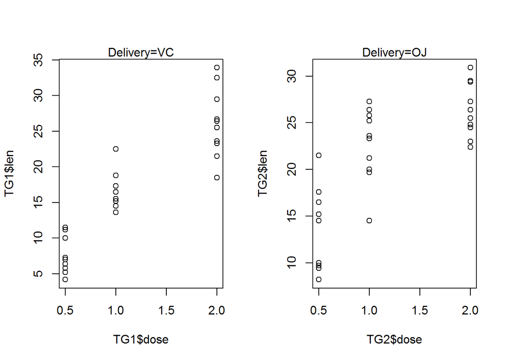

```r
par(mfrow=c(1,2)); plot(TG1$dose,TG1$len);mtext("Delivery=VC");
plot(TG2$dose,TG2$len); mtext("Delivery=OJ")
```

Now we will complete a t-test on the difference between the delivery mechanisms to see if the teeth lengths are larger with OJ delivery. The assumptions are that the variances are pooled and the samples are not paired (since each guineau pig recieves a distinct delivery mechanism).

```r
#now create the samples for
tg1<-TG1$len
tg2<-TG2$len

#we will do a t-test confidence interval with sample variance pooled
#and not paired examples (since the guieau pigs only have one treatment)
t.test(tg2, tg1, paired = FALSE, var.equal = TRUE)
```

```
##
##  Two Sample t-test
##
## data:  tg2 and tg1
## t = 2.0735, df = 59, p-value = 0.0425
## alternative hypothesis: true difference in means is not equal to 0
## 95 percent confidence interval:
##  0.1393905 7.8307170
## sample estimates:
## mean of x mean of y
##  20.94839  16.96333
```

## Conclusion

A P value of 4.25% shows at the 5% confidence interval the OJ delivery is more effective than VC. In addition, the confidence interval [0.14,7.83] excludes zero again showing the teeth lengths are longer with OJ than VC.

The result is not very strong since the increased variance of results diminishes the strength of the test statistic

## Appendix

As an asside, we will complete the dose-wise tests:

Dose=0.5 [2.5,12.0]. OJ is statistically much more effective than VC at low doses.  
Dose=1.0 [0.3,8.1] - OJ is a bit moroe effective than VC at moderate doses. Dose=2.0 [-3.2, 3.9] - OJ is not more effective than VC at high doses.

```r
d=c(1:10); t.test(tg2[d], tg1[d], paired = FALSE, var.equal = TRUE)
```

```
##
##  Two Sample t-test
##
## data:  tg2[d] and tg1[d]
## t = 3.1982, df = 18, p-value = 0.004982
## alternative hypothesis: true difference in means is not equal to 0
## 95 percent confidence interval:
##   2.480568 11.979432
## sample estimates:
## mean of x mean of y
##     15.21      7.98
```

```r
d=c(11:20); t.test(tg2[d], tg1[d], paired = FALSE, var.equal = TRUE)
```

```
##
##  Two Sample t-test
##
## data:  tg2[d] and tg1[d]
## t = 2.2416, df = 18, p-value = 0.03783
## alternative hypothesis: true difference in means is not equal to 0
## 95 percent confidence interval:
##  0.2616513 8.0783487
## sample estimates:
## mean of x mean of y
##     20.94     16.77
```

```r
d=c(21:30); t.test(tg2[d], tg1[d], paired = FALSE, var.equal = TRUE)
```

```
##
##  Two Sample t-test
##
## data:  tg2[d] and tg1[d]
## t = 0.20555, df = 18, p-value = 0.8394
## alternative hypothesis: true difference in means is not equal to 0
## 95 percent confidence interval:
##  -3.227282  3.927282
## sample estimates:
## mean of x mean of y
##     26.49     26.14
```